# Discrete Random Variables & Distributions in R

STAT 521

This section introduces R’s naming convention for probability distribution functions. It explains how the four prefixes **d**, **p**, **q**, and **r** are used to access the probability mass/density, cumulative distribution, quantile, and random sampling functions for each distribution.

R uses a consistent naming scheme for distribution-related functions. Replace `<name>` with the distribution code:

- **`d<name>`** — *density/pmf* (for discrete: probability mass function)  
  Returns $f_X(x) = \mathbb{P}(X = x)$.
- **`p<name>`** — *cdf*  
  Returns $F_X(x) = \mathbb{P}(X \le x)$.
- **`q<name>`** — *quantile* (inverse cdf)  
  Returns $x$ such that $F_X(x) \ge p$.
- **`r<name>`** — *random generation* (samples)  
  Returns i.i.d. draws from the distribution.

Common **discrete** `<name>` codes in base R (package **stats**):

| Distribution | `<name>` | Example calls (pmf/cdf/sim) | Notes |
| --- | --- | --- | --- |
| Bernoulli(p) | `binom` | `dbinom(1,1,p)`, `pbinom(0,1,p)`, `rbinom(n,1,p)` | Bernoulli is Binomial with `size = 1`. |
| Binomial(n,p) | `binom` | `dbinom(x,n,p)`, `pbinom(x,n,p)`, `rbinom(nn,n,p)` | Parameterization: `size = n`, `prob = p`. |
| Geometric(p) | `geom` | `dgeom(x,p)`, `pgeom(x,p)`, `rgeom(n,p)` | **Counts failures** before first success. |
| Neg. Binomial(r,p) | `nbinom` | `dnbinom(x,r,p)`, `pnbinom(x,r,p)`, `rnbinom(n,r,p)` | **Counts failures** before the `r`-th success (`size = r`). |
| Poisson(λ) | `pois` | `dpois(x,λ)`, `ppois(x,λ)`, `rpois(n,λ)` | Support $x=0,1,2,\dots$. |
| Hypergeometric | `hyper` | `dhyper(x,m,n,k)`, `phyper(…)`, `rhyper(…)` | Without replacement: `m` success, `n` failure in population, draw `k`. |
| Discrete custom | — | `sample(x, size, replace=TRUE, prob=p)` | Finite-support distributions via weights. |

> Tip: use `?dbinom` etc. to see full documentation for arguments and conventions.

## Bernoulli and Binomial

Here we show how the Bernoulli distribution is a special case of the Binomial distribution with size = 1. We also simulate from a general Binomial and compare empirical mean/variance to the theoretical values.

```r
# Bernoulli(p) as Binomial(size=1, p)
p <- 0.3
x_bern <- rbinom(n = 10000, size = 1, prob = p)

# Quick checks
mean(x_bern)            # ≈ p
```

```
## [1] 0.3048
```

```r
var(x_bern)             # ≈ p(1-p)
```

```
## [1] 0.2119182
```

```r
# Binomial(n, p)
n <- 20; p <- 0.4
x_bin <- rbinom(n = 10000, size = n, prob = p)
c(mean = mean(x_bin), var = var(x_bin),
  theory_mean = n*p, theory_var = n*p*(1-p))
```

```
##        mean         var theory_mean  theory_var
##    8.011600    4.813747    8.000000    4.800000
```

### LLN: Running mean for Bernoulli(0.3)

This section illustrates the Law of Large Numbers by plotting the running sample mean of Bernoulli draws against the true probability.

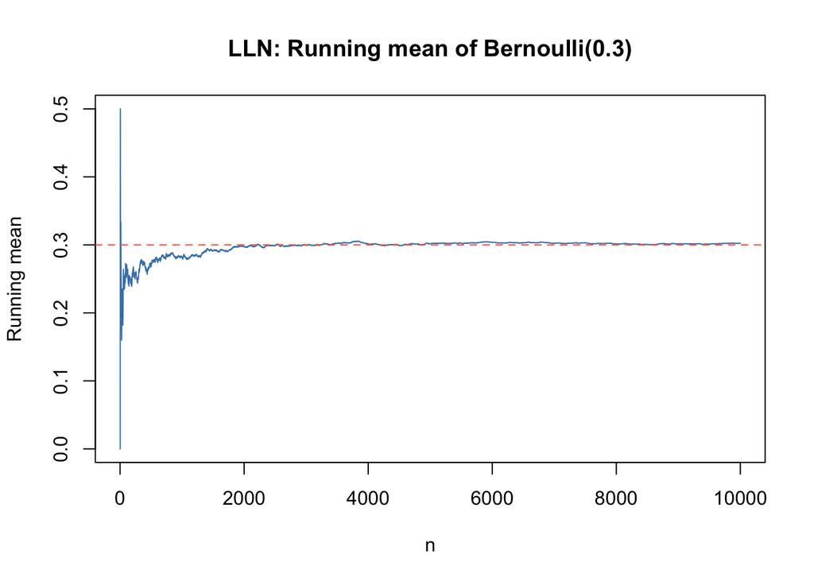

```r
p <- 0.3
x <- rbinom(10000, 1, p)
running_mean <- cumsum(x) / seq_along(x)

plot(running_mean, type = "l", col= "steelblue",
     xlab = "n", ylab = "Running mean",
     main = "LLN: Running mean of Bernoulli(0.3)")
abline(h = p, lty = 2, col="tomato")
```

## Geometric and Negative Binomial

*(R’s parameterization counts **failures** before success)*

This subsection explores waiting-time distributions. The geometric counts failures before the first success, while the negative binomial generalizes this to the number of failures before the r-th success.

```r
# Geometric(p): number of failures before first success
p <- 0.25
x_geom <- rgeom(n = 10000, prob = p)
c(mean = mean(x_geom), var = var(x_geom),
  theory_mean = (1-p)/p, theory_var = (1-p)/p^2)
```

```
##        mean         var theory_mean  theory_var
##     3.07950    12.74865     3.00000    12.00000
```

```r
# Negative Binomial(r, p): failures before r-th success
r <- 5; p <- 0.4
x_nbin <- rnbinom(n = 10000, size = r, prob = p)
c(mean = mean(x_nbin), var = var(x_nbin),
  theory_mean = r*(1-p)/p, theory_var = r*(1-p)/p^2)
```

```
##        mean         var theory_mean  theory_var
##     7.59640    18.69838     7.50000    18.75000
```

```r
# Probability that the # of failures before 3rd success is <= 10
r <- 3; p <- 0.25
# X ~ NegBin(r,p) counts failures before r-th success
p_cdf <- pnbinom(q = 10, size = r, prob = p)
p_cdf
```

```
## [1] 0.6673983
```

## Poisson

This subsection illustrates the Poisson distribution, which models counts of events with a constant rate λ, and shows how its empirical mean/variance align with the theory.

```r
lambda <- 3.5
x_pois <- rpois(n = 50000, lambda = lambda)
c(mean = mean(x_pois), var = var(x_pois), theory = lambda)
```

```
##     mean      var   theory
## 3.494140 3.485355 3.500000
```

## Hypergeometric (finite population, without replacement)

This part shows the hypergeometric distribution, which arises in finite populations when sampling without replacement. We compare empirical estimates with the finite-population mean/variance formulas.

```r
# Population: 100 items, m = 40 "successes", n = 60 "failures"
m <- 40        # successes in population
n_fail <- 60   # failures in population
kdraw <- 12    # number of draws (sample size)
x_hyp <- rhyper(20000, m = m, n = n_fail, k = kdraw)

# Theoretical mean and var
N <- m + n_fail
theory_mean <- kdraw * m / N
theory_var  <- kdraw * (m/N) * (1 - m/N) * (N - kdraw) / (N - 1)
c(mean = mean(x_hyp), var = var(x_hyp), theory_mean = theory_mean, theory_var = theory_var)
```

```
##        mean         var theory_mean  theory_var
##    4.812150    2.540889    4.800000    2.560000
```

## Finite custom discrete with `sample()`

This example shows how to create custom discrete distributions with arbitrary support using `sample()` with specified probabilities.

```r
support <- c(-1, 0, 2, 5)
pmf     <- c(0.1, 0.2, 0.5, 0.2)   # must sum to 1
x_custom <- sample(support, size = 20000, replace = TRUE, prob = pmf)

# Theoretical mean/var vs empirical
mu_theory <- sum(support * pmf)
var_theory <- sum((support - mu_theory)^2 * pmf)
c(mean = mean(x_custom), var = var(x_custom), mu_theory = mu_theory, var_theory = var_theory)
```

```
##       mean        var  mu_theory var_theory
##   1.938450   3.508137   1.900000   3.490000
```

## Poisson approximation to Binomial

Consider a Binomial random variable
$$X \sim \mathrm{Binomial}(n,p), \quad
\mathbb{P}(X=k) = \binom{n}{k} p^k (1-p)^{n-k}, \quad k=0,1,\dots,n.$$

When $n$ is large and $p$ is small, with $\lambda = np$ held fixed, the Binomial distribution can be approximated by a Poisson distribution:
$$X \approx Y \sim \mathrm{Poisson}(\lambda),
\quad \mathbb{P}(Y=k) = e^{-\lambda}\frac{\lambda^k}{k!},
\quad k=0,1,2,\dots$$

Start with the Binomial pmf:
$$\mathbb{P}(X=k) = \binom{n}{k} p^k (1-p)^{n-k}.$$
Substitute $p = \tfrac{\lambda}{n}$:
$$\mathbb{P}(X=k) = \binom{n}{k} \left(\frac{\lambda}{n}\right)^k
\left(1-\frac{\lambda}{n}\right)^{n-k}.$$

As $n \to \infty$,
$$\binom{n}{k}\left(\frac{1}{n}\right)^k \to \frac{1}{k!},
\qquad \left(1-\frac{\lambda}{n}\right)^n \to e^{-\lambda}.$$

Therefore,
$$\mathbb{P}(X=k) \;\to\; e^{-\lambda}\frac{\lambda^k}{k!},$$
which is exactly the Poisson pmf.

The Poisson approximation is accurate when:
$$n \text{ is large}, \quad p \text{ is small}, \quad \lambda = np \text{
is moderate}.$$
It is commonly used for modeling the number of rare events in a large number of trials.

The following code shows how the Poisson distribution approximates the Binomial when n is large and p is small. It includes a comparison of PMFs and computes the total variation distance between them.

```r
n <- 100; p <- 0.03; lambda <- n*p
k <- 0:20
pmf_binom <- dbinom(k, size = n, prob = p)
pmf_pois  <- dpois(k, lambda = lambda)

# Approximate total variation distance over this support
tvd <- 0.5 * sum(abs(pmf_binom - pmf_pois))
tvd
```

```
## [1] 0.007606967
```

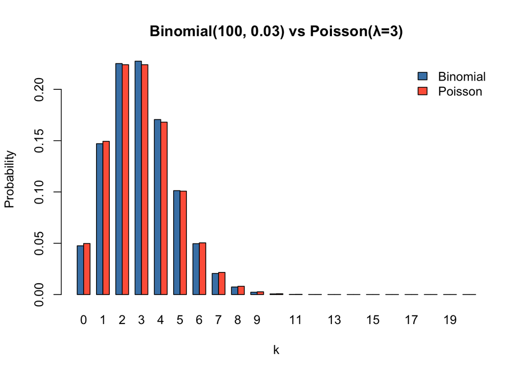

```r
mat <- rbind(Binomial = pmf_binom, Poisson = pmf_pois)
bp <- barplot(mat, beside = TRUE,
              col = c("steelblue", "tomato"),
              names.arg = k, xlab = "k", ylab = "Probability",
              main = "Binomial(100, 0.03) vs Poisson(λ=3)")
legend("topright", fill = c("steelblue", "tomato"),
       legend = rownames(mat), bty = "n")
```

## Monte Carlo Methods: Origin and Definition

The term **Monte Carlo** comes from the famous casino in Monaco. The connection to gambling games of chance such as roulette and dice inspired the name *Monte Carlo*.

In the 1940s, Stanislaw Ulam and John von Neumann began using random numbers to solve complex mathematical and physical problems, notably during the Manhattan Project. The Manhattan Project was the secret U.S. led research and development project during World War II that produced the first nuclear weapons. During this project, Ulam and von Neumann worked at Los Alamos, where they developed early Monte Carlo methods to model neutron diffusion in nuclear reactions.

**General Definition.**
A Monte Carlo method is a computational technique that relies on **repeated random sampling** to approximate numerical results. If a quantity can be expressed as an expectation
$$\theta = \mathbb{E}[f(X)],$$
then it can be approximated by simulating $R$ independent samples $X^{(1)}, \dots, X^{(R)}$ and taking the average:
$$\widehat{\theta} = \frac{1}{R} \sum_{i=1}^R f\!\left(X^{(i)}\right).$$

By the **Law of Large Numbers**, as $R \to \infty$,
$$\widehat{\theta} \;\to\; \theta \quad \text{(in probability)}.$$

**Applications.** Monte Carlo methods are widely used for:

- Approximating probabilities or expectations when exact formulas are intractable,
- Numerical integration in high dimensions,
- Simulating complex random processes in fields such as physics, finance, and statistics.

#### Example: Monte Carlo probability

This section uses Monte Carlo simulation and the negative binomial distribution to estimate the probability of obtaining 3 sixes in 20 or fewer dice rolls, and compares simulation to the theoretical CDF.

Let $T$ be the number of *rolls* to get 3 sixes. Then $T-3 \sim \mathrm{NegBin}(r=3, p=1/6)$ (failures before the 3rd success). We estimate $\mathbb{P}(T \le 20)$ and compare to theory.

In the following code you are repeatedly simulating (100,000 times) the random process “roll dice until you see 3 sixes,” using the negative binomial generator. Then you approximate the probability $\mathbb{P}(T \le 20)$ by the fraction of simulations in which it happened.

```r
set.seed(521)
R <- 100000
# Simulate directly via negative binomial for failures:
failures <- rnbinom(R, size = 3, prob = 1/6)  # failures before 3rd six
T_sim <- failures + 3
mean(T_sim <= 20)
```

```
## [1] 0.67184
```

That’s what makes it **Monte Carlo**: using repeated random draws to approximate a probability that you could in principle calculate exactly.

The following code computes the exact probability using the cumulative distribution function of the negative binomial. No simulation, just a closed-form calculation.

```r
# Theoretical via CDF of failures
p_theory <- pnbinom(q = 20 - 3, size = 3, prob = 1/6)
p_theory
```

```
## [1] 0.6713409
```